# Religion and Wellbeing

Scott Claessens

2021-09-17

# Initial religion PCA and data organisation

To find a single predictor for our models that captures “religiosity”, we first run a principal components analysis with all nine of the religion items to see how many factors it produces.

A scree plot of this PCA reveals that a single factor is enough.

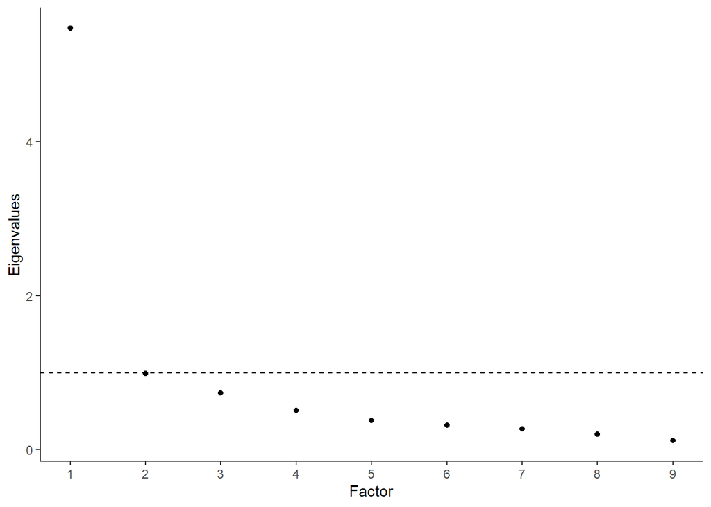

For modelling, we then (1) add this principal component to the dataset as `religion`, (2) create a composite variable of `cnorm_1` and `cnorm_2` called `cnorm`, and (3) organise the data in long format. The data then look like this (only the top 20 rows):

| wellbeing | item | subscale | religion | cnorm | subject | country | denomination | age | gender | gdp_scaled |
| --- | --- | --- | --- | --- | --- | --- | --- | --- | --- | --- |
| 4 | wb_gen_1 | gen | -0.5737776 | 0.50 | 1 | Australia | No denomination specified | 0.5235262 | man | 1.001802 |
| 2 | wb_gen_2 | gen | -0.5737776 | 0.50 | 1 | Australia | No denomination specified | 0.5235262 | man | 1.001802 |
| 3 | wb_phys_1 | phys | -0.5737776 | 0.50 | 1 | Australia | No denomination specified | 0.5235262 | man | 1.001802 |
| 3 | wb_phys_2 | phys | -0.5737776 | 0.50 | 1 | Australia | No denomination specified | 0.5235262 | man | 1.001802 |
| 3 | wb_phys_3 | phys | -0.5737776 | 0.50 | 1 | Australia | No denomination specified | 0.5235262 | man | 1.001802 |
| 4 | wb_phys_4 | phys | -0.5737776 | 0.50 | 1 | Australia | No denomination specified | 0.5235262 | man | 1.001802 |
| 2 | wb_phys_5 | phys | -0.5737776 | 0.50 | 1 | Australia | No denomination specified | 0.5235262 | man | 1.001802 |
| 3 | wb_phys_6 | phys | -0.5737776 | 0.50 | 1 | Australia | No denomination specified | 0.5235262 | man | 1.001802 |
| 2 | wb_phys_7 | phys | -0.5737776 | 0.50 | 1 | Australia | No denomination specified | 0.5235262 | man | 1.001802 |
| 1 | wb_psych_1 | psych | -0.5737776 | 0.50 | 1 | Australia | No denomination specified | 0.5235262 | man | 1.001802 |
| 1 | wb_psych_2 | psych | -0.5737776 | 0.50 | 1 | Australia | No denomination specified | 0.5235262 | man | 1.001802 |
| 3 | wb_psych_3 | psych | -0.5737776 | 0.50 | 1 | Australia | No denomination specified | 0.5235262 | man | 1.001802 |
| 3 | wb_psych_4 | psych | -0.5737776 | 0.50 | 1 | Australia | No denomination specified | 0.5235262 | man | 1.001802 |
| 2 | wb_psych_5 | psych | -0.5737776 | 0.50 | 1 | Australia | No denomination specified | 0.5235262 | man | 1.001802 |
| 3 | wb_psych_6 | psych | -0.5737776 | 0.50 | 1 | Australia | No denomination specified | 0.5235262 | man | 1.001802 |
| 3 | wb_soc_1 | soc | -0.5737776 | 0.50 | 1 | Australia | No denomination specified | 0.5235262 | man | 1.001802 |
| 1 | wb_soc_2 | soc | -0.5737776 | 0.50 | 1 | Australia | No denomination specified | 0.5235262 | man | 1.001802 |
| 3 | wb_soc_3 | soc | -0.5737776 | 0.50 | 1 | Australia | No denomination specified | 0.5235262 | man | 1.001802 |
| 4 | wb_gen_1 | gen | 0.6743128 | 0.25 | 2 | Australia | Christian (Roman Catholic) | -0.1998611 | man | 1.001802 |
| 3 | wb_gen_2 | gen | 0.6743128 | 0.25 | 2 | Australia | Christian (Roman Catholic) | -0.1998611 | man | 1.001802 |

# Models without controlling for linguistic distance between countries

## Question 1: Does religiosity predict wellbeing?

First, we fit a “null” random-intercept-only ordinal Bayesian multilevel model. This model includes demographic control variables (age, gender, and GDP) and random intercepts for wellbeing items nested within wellbeing subscales, and for participants within countries and denominations: `wellbeing ~ 1 + (1 | subscale/item) + (1 | iso) + (1 | denomination) + (1 | subject) + age + gender + gdp_scaled`.

Here’s the summary for this model.

```
##  Family: cumulative
##   Links: mu = logit; disc = identity
## Formula: wellbeing ~ 1 + (1 | subscale/item) + (1 | iso) + (1 | denomination) + (1 | subject) + age + gender + gdp_scaled
##    Data: dLong (Number of observations: 182200)
## Samples: 4 chains, each with iter = 2500; warmup = 1250; thin = 1;
##          total post-warmup samples = 5000
##
## Group-Level Effects:
## ~denomination (Number of levels: 21)
##               Estimate Est.Error l-95% CI u-95% CI Rhat Bulk_ESS Tail_ESS
## sd(Intercept)     0.11      0.03     0.06     0.19 1.01     1107     2155
##
## ~iso (Number of levels: 24)
##               Estimate Est.Error l-95% CI u-95% CI Rhat Bulk_ESS Tail_ESS
## sd(Intercept)     0.41      0.07     0.31     0.56 1.00     1368     2386
##
## ~subject (Number of levels: 10175)
##               Estimate Est.Error l-95% CI u-95% CI Rhat Bulk_ESS Tail_ESS
## sd(Intercept)     1.30      0.01     1.28     1.32 1.00     1380     2473
##
## ~subscale (Number of levels: 4)
##               Estimate Est.Error l-95% CI u-95% CI Rhat Bulk_ESS Tail_ESS
## sd(Intercept)     0.31      0.21     0.02     0.80 1.01      967     1656
##
## ~subscale:item (Number of levels: 18)
##               Estimate Est.Error l-95% CI u-95% CI Rhat Bulk_ESS Tail_ESS
## sd(Intercept)     0.64      0.12     0.45     0.91 1.00     1589     2657
##
## Population-Level Effects:
##              Estimate Est.Error l-95% CI u-95% CI Rhat Bulk_ESS Tail_ESS
## Intercept[1]    -4.36      0.26    -4.82    -3.78 1.00     1911     2503
## Intercept[2]    -2.40      0.26    -2.87    -1.83 1.00     1913     2558
## Intercept[3]    -0.70      0.26    -1.17    -0.13 1.00     1915     2488
## Intercept[4]     1.79      0.26     1.32     2.36 1.00     1914     2515
## age              0.05      0.02     0.01     0.08 1.00      935     1255
## genderother     -0.79      0.17    -1.11    -0.46 1.00     1088     1663
## genderwoman     -0.09      0.03    -0.14    -0.03 1.00      834     2113
## gdp_scaled       0.01      0.09    -0.16     0.19 1.00     1064     1887
##
## Family Specific Parameters:
##      Estimate Est.Error l-95% CI u-95% CI Rhat Bulk_ESS Tail_ESS
## disc     1.00      0.00     1.00     1.00 1.00     5000     5000
##
## Samples were drawn using sampling(NUTS). For each parameter, Bulk_ESS
## and Tail_ESS are effective sample size measures, and Rhat is the potential
## scale reduction factor on split chains (at convergence, Rhat = 1).
```

We get cutpoints for the ordinal intercept, main effects for the demographic control variables, and standard deviations from the random effects.

Next, we add a fixed effect for the religiosity predictor, as well as (1) a random slope grouped by wellbeing item nested within subscale, (2) a random slope grouped by country, and (3) a random slope grouped by denomination: `wellbeing ~ 1 + religion + (1 + religion | subscale/item) + (1 + religion | iso) + (1 + religion | denomination) + (1 | subject) + age + gender + gdp_scaled`. This gives us a different effect of religion for every wellbeing subscale, every wellbeing item, every country, and every religious denomination.

Does this second model improve the fit? We would expect it to if `religion` is a good predictor of wellbeing.

```
##      elpd_diff se_diff subsampling_se_diff
## m1.2    0.0       0.0     0.0
## m1.1 1221.3      59.8   267.8
```

What’s the summary for this model?

```
##  Family: cumulative
##   Links: mu = logit; disc = identity
## Formula: wellbeing ~ 1 + religion + (1 + religion | subscale/item) + (1 + religion | iso) + (1 + religion | denomination) + (1 | subject) + age + gender + gdp_scaled
##    Data: dLong (Number of observations: 182200)
## Samples: 4 chains, each with iter = 2500; warmup = 1250; thin = 1;
##          total post-warmup samples = 5000
##
## Group-Level Effects:
## ~denomination (Number of levels: 21)
##                         Estimate Est.Error l-95% CI u-95% CI Rhat Bulk_ESS Tail_ESS
## sd(Intercept)               0.22      0.08     0.07     0.40 1.03      135       63
## sd(religion)                0.13      0.06     0.02     0.26 1.03      113       44
## cor(Intercept,religion)    -0.88      0.23    -1.00    -0.27 1.02      239       98
##
## ~iso (Number of levels: 24)
##                         Estimate Est.Error l-95% CI u-95% CI Rhat Bulk_ESS Tail_ESS
## sd(Intercept)               0.41      0.06     0.30     0.55 1.01     1019     1982
## sd(religion)                0.14      0.03     0.10     0.21 1.01      687     1327
## cor(Intercept,religion)    -0.45      0.19    -0.77    -0.03 1.00      922     1468
##
## ~subject (Number of levels: 10175)
##               Estimate Est.Error l-95% CI u-95% CI Rhat Bulk_ESS Tail_ESS
## sd(Intercept)     1.29      0.01     1.27     1.31 1.00      958     1988
##
## ~subscale (Number of levels: 4)
##                         Estimate Est.Error l-95% CI u-95% CI Rhat Bulk_ESS Tail_ESS
## sd(Intercept)               0.22      0.17     0.01     0.65 1.00      673     1693
## sd(religion)                0.10      0.09     0.00     0.32 1.00      821     1355
## cor(Intercept,religion)    -0.27      0.54    -0.98     0.87 1.00     1618     2105
##
## ~subscale:item (Number of levels: 18)
##                         Estimate Est.Error l-95% CI u-95% CI Rhat Bulk_ESS Tail_ESS
## sd(Intercept)               0.66      0.12     0.47     0.94 1.00     1055     1952
## sd(religion)                0.23      0.04     0.16     0.33 1.00      974     1879
## cor(Intercept,religion)    -0.56      0.17    -0.82    -0.17 1.00     1039     1731
##
## Population-Level Effects:
##              Estimate Est.Error l-95% CI u-95% CI Rhat Bulk_ESS Tail_ESS
## Intercept[1]    -4.15      0.24    -4.60    -3.67 1.01      644     1364
## Intercept[2]    -2.18      0.24    -2.63    -1.69 1.01      639     1346
## Intercept[3]    -0.47      0.24    -0.92     0.02 1.01      645     1339
## Intercept[4]     2.04      0.24     1.59     2.53 1.01      644     1363
## religion         0.32      0.11     0.12     0.53 1.01      510     1141
## age              0.05      0.02     0.02     0.08 1.01      453      849
## genderother     -0.75      0.17    -1.08    -0.43 1.00      699     1081
## genderwoman     -0.09      0.03    -0.15    -0.03 1.00      474     1096
## gdp_scaled       0.04      0.08    -0.12     0.19 1.00      572     1211
##
## Family Specific Parameters:
##      Estimate Est.Error l-95% CI u-95% CI Rhat Bulk_ESS Tail_ESS
## disc     1.00      0.00     1.00     1.00 1.00     5000     5000
##
## Samples were drawn using sampling(NUTS). For each parameter, Bulk_ESS
## and Tail_ESS are effective sample size measures, and Rhat is the potential
## scale reduction factor on split chains (at convergence, Rhat = 1).
```

The fixed effect of `religion` is of interest.

Let’s visualise the effect of religiosity on *overall* wellbeing.

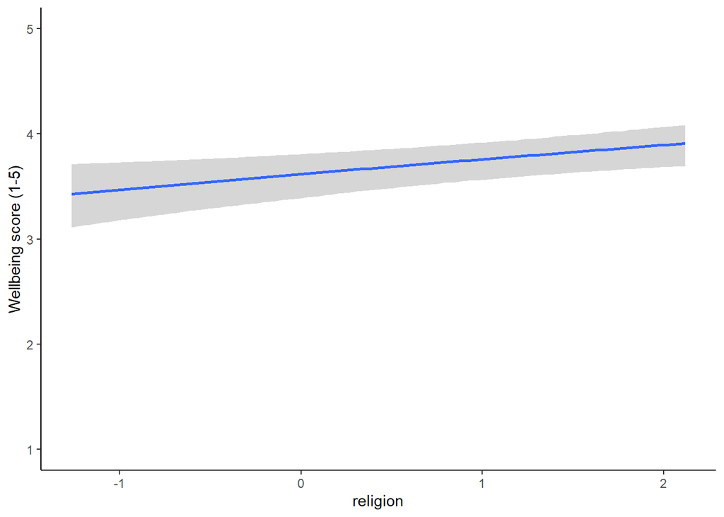

We can also split this effect into separate wellbeing subscales…

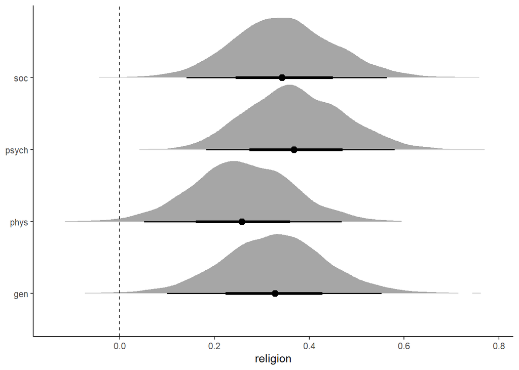

… and by individual wellbeing items…

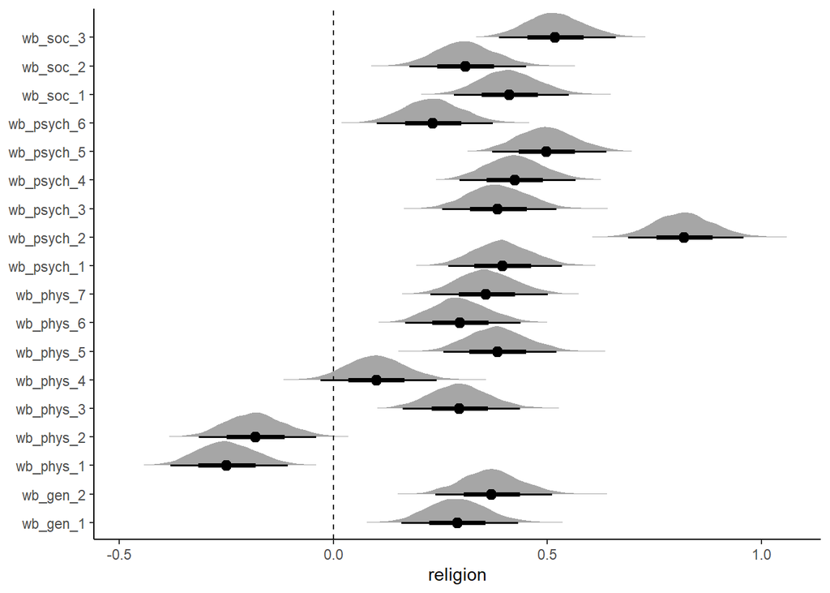

… and by country…

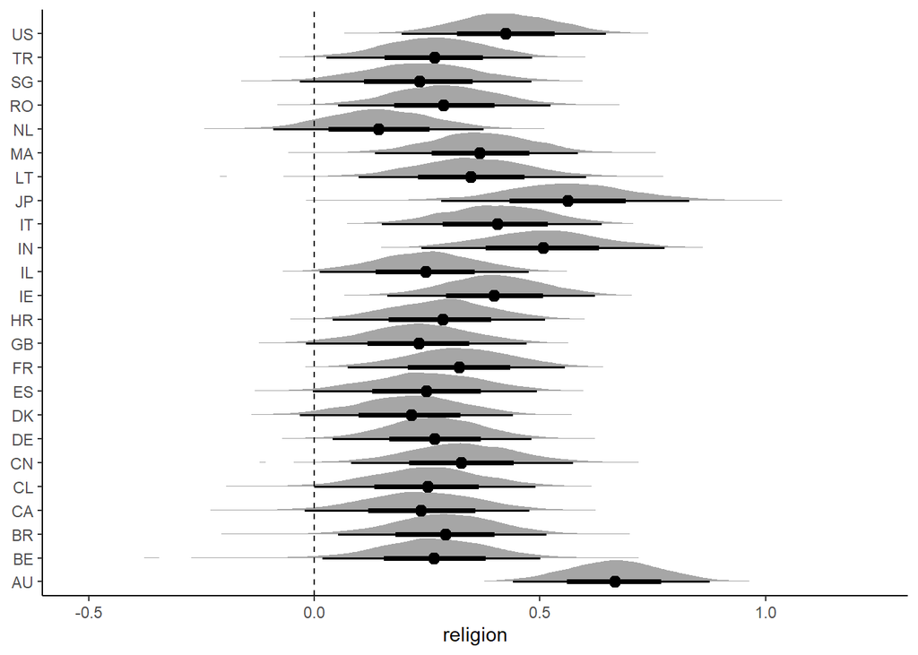

… and by religious denomination.

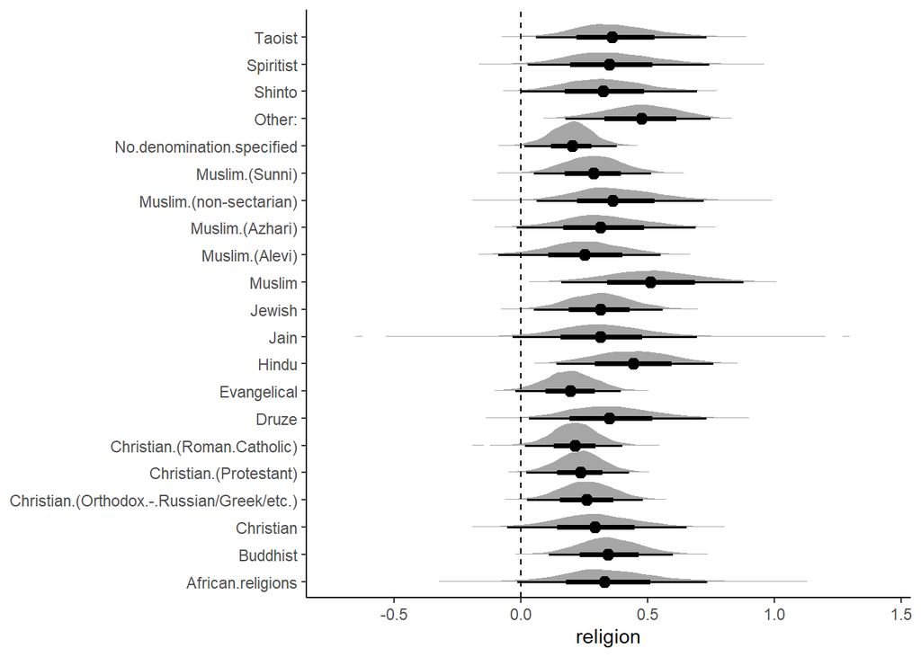

## Question 2: Is there an interaction with perceived cultural norms?

We then add a fixed interaction effect with `cnorm`, and allow this interaction effect to vary as a random slope over wellbeing items nested within subscales, as a random slope over countries, and as a random slope over denominations: `wellbeing ~ 1 + religion*cnorm + (1 + religion*cnorm | subscale/item) + (1 + religion*cnorm | iso) + (1 + religion*cnorm | denomination) + (1 | subject) + age + gender + gdp_scaled`. In this model, every wellbeing subscale, every individual wellbeing item, every country, and every denomination has its own interaction between religion and cultural norms.

Does this model improve the fit over the previous model? If there’s an interaction effect, we would expect it to.

```
##      elpd_diff se_diff subsampling_se_diff
## m1.3   0.0       0.0     0.0
## m1.2 256.7      34.1   267.0
```

Here’s the summary for this model.

```
##  Family: cumulative
##   Links: mu = logit; disc = identity
## Formula: wellbeing ~ 1 + religion * cnorm + (1 + religion * cnorm | subscale/item) + (1 + religion * cnorm | iso) + (1 + religion * cnorm | denomination) + (1 | subject) + age + gender + gdp_scaled
##    Data: dLong (Number of observations: 182200)
## Samples: 4 chains, each with iter = 2500; warmup = 1250; thin = 1;
##          total post-warmup samples = 5000
##
## Group-Level Effects:
## ~denomination (Number of levels: 21)
##                               Estimate Est.Error l-95% CI u-95% CI Rhat Bulk_ESS Tail_ESS
## sd(Intercept)                     0.13      0.07     0.01     0.29 1.01      392      671
## sd(religion)                      0.07      0.05     0.00     0.18 1.01      472     1789
## sd(cnorm)                         0.15      0.10     0.01     0.39 1.01      608     1335
## sd(religion:cnorm)                0.08      0.06     0.00     0.23 1.01      993     1819
## cor(Intercept,religion)          -0.39      0.44    -0.95     0.64 1.00      816     2238
## cor(Intercept,cnorm)              0.03      0.42    -0.75     0.79 1.00     2375     3029
## cor(religion,cnorm)              -0.23      0.43    -0.89     0.70 1.00     1613     2847
## cor(Intercept,religion:cnorm)    -0.23      0.44    -0.90     0.70 1.00     2112     2711
## cor(religion,religion:cnorm)     -0.01      0.43    -0.79     0.80 1.00     2909     3500
## cor(cnorm,religion:cnorm)        -0.20      0.45    -0.90     0.73 1.00     2266     3048
##
## ~iso (Number of levels: 24)
##                               Estimate Est.Error l-95% CI u-95% CI Rhat Bulk_ESS Tail_ESS
## sd(Intercept)                     0.47      0.07     0.35     0.63 1.00     1770     2567
## sd(religion)                      0.05      0.03     0.00     0.13 1.01      554     1239
## sd(cnorm)                         0.26      0.10     0.04     0.46 1.02      213      151
## sd(religion:cnorm)                0.19      0.07     0.04     0.33 1.01      361      488
## cor(Intercept,religion)          -0.36      0.37    -0.90     0.50 1.00     1877     2768
## cor(Intercept,cnorm)             -0.46      0.25    -0.86     0.14 1.00     1329     1155
## cor(religion,cnorm)               0.16      0.41    -0.69     0.84 1.00      703     1555
## cor(Intercept,religion:cnorm)    -0.23      0.30    -0.74     0.42 1.00     1557     2516
## cor(religion,religion:cnorm)     -0.11      0.42    -0.81     0.74 1.01      538     1692
## cor(cnorm,religion:cnorm)         0.46      0.32    -0.26     0.92 1.00      986     1445
##
## ~subject (Number of levels: 10175)
##               Estimate Est.Error l-95% CI u-95% CI Rhat Bulk_ESS Tail_ESS
## sd(Intercept)     1.29      0.01     1.27     1.31 1.00     1147     2339
##
## ~subscale (Number of levels: 4)
##                               Estimate Est.Error l-95% CI u-95% CI Rhat Bulk_ESS Tail_ESS
```

[output cut: 30 more lines]

```
## religion           0.15      0.10    -0.03     0.35 1.00     1093     1819
## cnorm              0.15      0.16    -0.18     0.45 1.00     1358     2489
## age                0.05      0.02     0.02     0.09 1.01      730     1426
## genderother       -0.77      0.17    -1.11    -0.44 1.00      930     2228
## genderwoman       -0.09      0.03    -0.14    -0.03 1.00      958     1784
## gdp_scaled         0.07      0.08    -0.10     0.23 1.00     1253     2476
## religion:cnorm     0.20      0.14    -0.07     0.47 1.01     1339     2219
##
## Family Specific Parameters:
##      Estimate Est.Error l-95% CI u-95% CI Rhat Bulk_ESS Tail_ESS
## disc     1.00      0.00     1.00     1.00 1.00     5000     5000
##
## Samples were drawn using sampling(NUTS). For each parameter, Bulk_ESS
## and Tail_ESS are effective sample size measures, and Rhat is the potential
## scale reduction factor on split chains (at convergence, Rhat = 1).
```

The fixed effect `religion:cnorm` is of interest.

Plot the interaction.

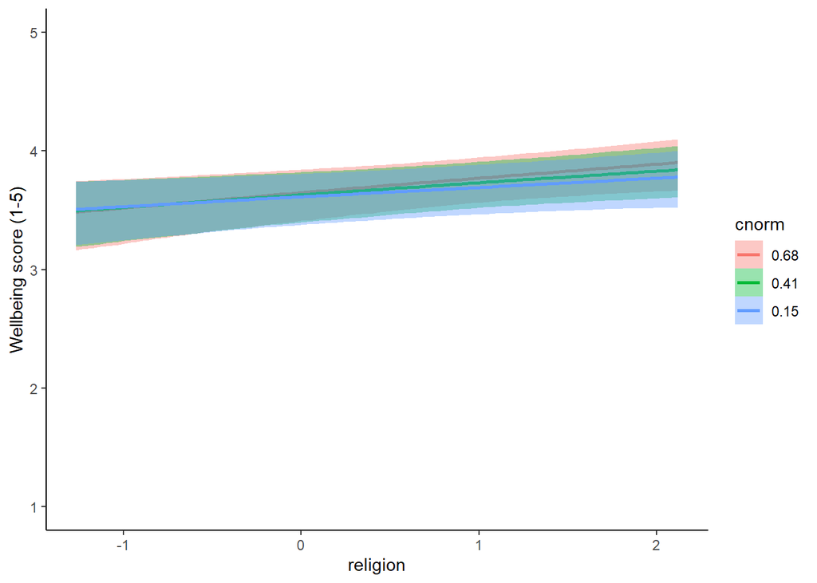

We can also get forest plots of the interaction parameter for wellbeing subscales…

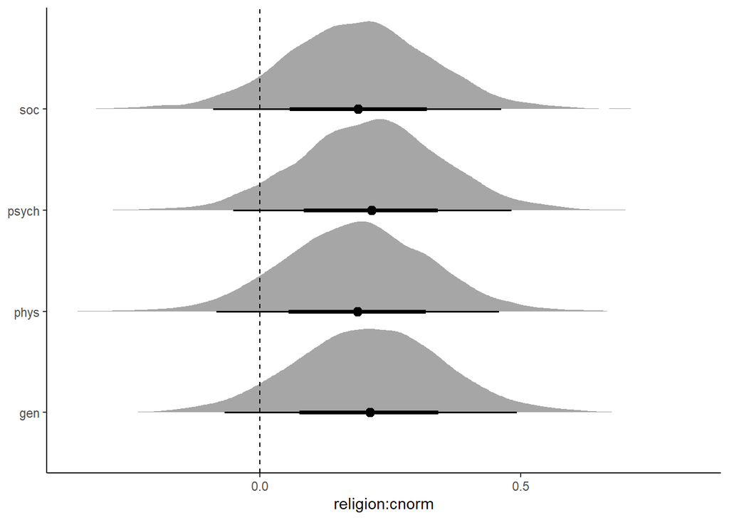

… for individual wellbeing items…

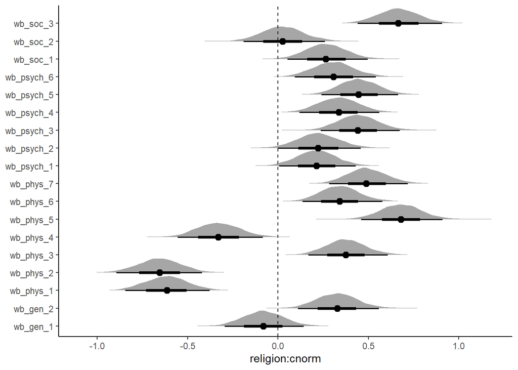

… for countries…

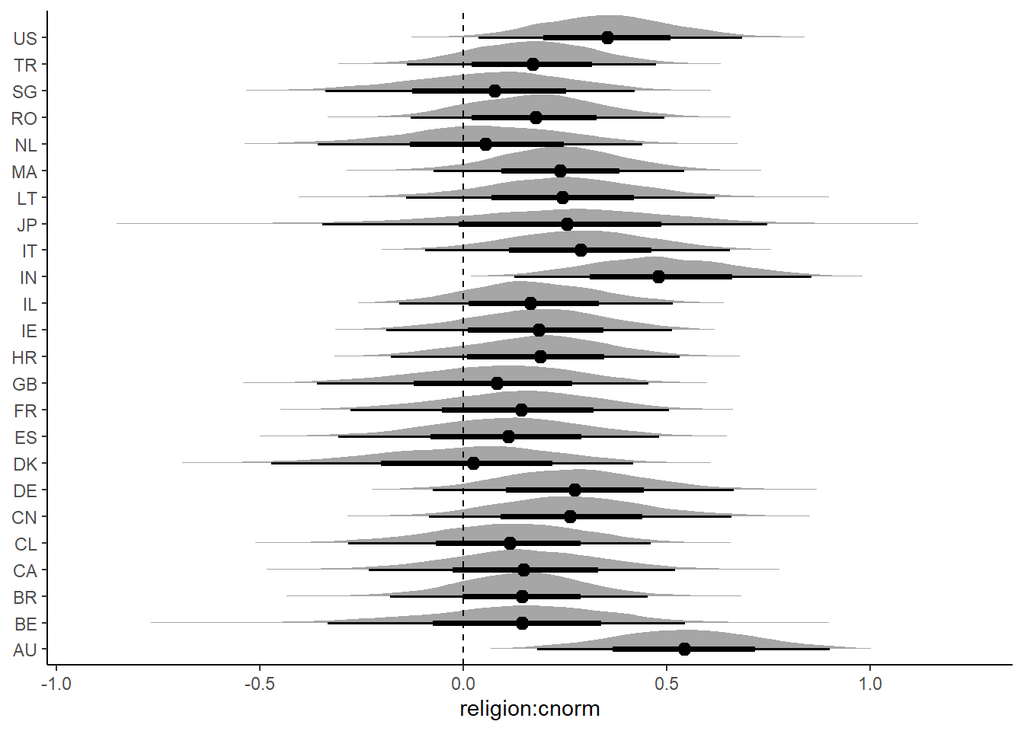

… and for religious denominations.

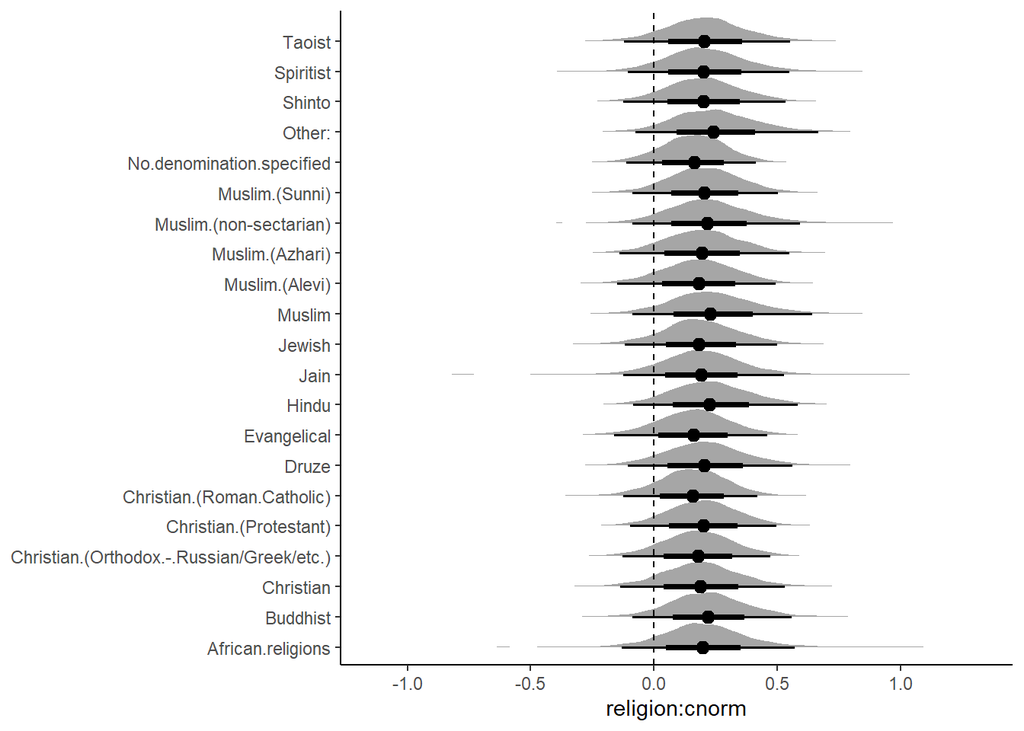

# Models controlling for linguistic distance between countries

Do our results change when we control for linguistic distance between countries? Some countries may have similar wellbeing scores simply because they are culturally similar.

## Question 1: Does religiosity predict wellbeing?

First, we fit a “null” random-intercept-only ordinal Bayesian multilevel model, controlling for linguistic distance for country random intercepts: `wellbeing ~ 1 + (1 | subscale/item) + (1 | gr(iso, cov = ling) + (1 | denomination) + (1 | subject) + age + gender + gdp_scaled`.

Here’s the summary for this model.

```
##  Family: cumulative
##   Links: mu = logit; disc = identity
## Formula: wellbeing ~ 1 + (1 | subscale/item) + (1 | gr(iso, cov = ling)) + (1 | denomination) + (1 | subject) + age + gender + gdp_scaled
##    Data: dLong (Number of observations: 182200)
## Samples: 4 chains, each with iter = 2500; warmup = 1250; thin = 1;
##          total post-warmup samples = 5000
##
## Group-Level Effects:
## ~denomination (Number of levels: 21)
##               Estimate Est.Error l-95% CI u-95% CI Rhat Bulk_ESS Tail_ESS
## sd(Intercept)     0.11      0.04     0.06     0.19 1.03      229      690
##
## ~iso (Number of levels: 24)
##               Estimate Est.Error l-95% CI u-95% CI Rhat Bulk_ESS Tail_ESS
## sd(Intercept)     0.46      0.07     0.34     0.63 1.02      362      851
##
## ~subject (Number of levels: 10175)
##               Estimate Est.Error l-95% CI u-95% CI Rhat Bulk_ESS Tail_ESS
## sd(Intercept)     1.30      0.01     1.28     1.32 1.01      454     1091
##
## ~subscale (Number of levels: 4)
##               Estimate Est.Error l-95% CI u-95% CI Rhat Bulk_ESS Tail_ESS
## sd(Intercept)     0.28      0.20     0.01     0.76 1.01      296      808
##
## ~subscale:item (Number of levels: 18)
##               Estimate Est.Error l-95% CI u-95% CI Rhat Bulk_ESS Tail_ESS
## sd(Intercept)     0.65      0.11     0.46     0.90 1.01      541     1190
##
## Population-Level Effects:
##              Estimate Est.Error l-95% CI u-95% CI Rhat Bulk_ESS Tail_ESS
## Intercept[1]    -4.23      0.29    -4.77    -3.64 1.02      414      780
## Intercept[2]    -2.27      0.28    -2.81    -1.70 1.02      414      779
## Intercept[3]    -0.58      0.28    -1.11     0.00 1.02      414      790
## Intercept[4]     1.91      0.28     1.38     2.50 1.02      414      782
## age              0.05      0.02     0.02     0.08 1.01      240      352
## genderother     -0.79      0.17    -1.12    -0.46 1.01      246      545
## genderwoman     -0.09      0.03    -0.15    -0.03 1.02      185      488
## gdp_scaled      -0.02      0.09    -0.19     0.15 1.00      308      783
##
## Family Specific Parameters:
##      Estimate Est.Error l-95% CI u-95% CI Rhat Bulk_ESS Tail_ESS
## disc     1.00      0.00     1.00     1.00 1.00     5000     5000
##
## Samples were drawn using sampling(NUTS). For each parameter, Bulk_ESS
## and Tail_ESS are effective sample size measures, and Rhat is the potential
## scale reduction factor on split chains (at convergence, Rhat = 1).
```

Next, we add the religiosity predictor: `wellbeing ~ 1 + religion + (1 + religion | subscale/item) + (1 | gr(iso, cov = ling, id = "iso")) + (0 + religion | gr(iso, id = "iso")) + (1 + religion | denomination) + (1 | subject) + age + gender + gdp_scaled`. We only allow the random intercept for countries (not the random slope) to covary according to linguistic distance, but still model the random intercept and random slope as correlated.

Does this second model improve the fit? We would expect it to if `religion` is a good predictor of wellbeing.

```
##      elpd_diff se_diff subsampling_se_diff
## m2.2    0.0       0.0     0.0
## m2.1 1564.3      60.0   220.9
```

What’s the summary for this model?

```
##  Family: cumulative
##   Links: mu = logit; disc = identity
## Formula: wellbeing ~ 1 + religion + (1 + religion | subscale/item) + (1 | gr(iso, cov = ling, id = "iso")) + (0 + religion | gr(iso, id = "iso")) + (1 + religion | denomination) + (1 | subject) + age + gender + gdp_scaled
##    Data: dLong (Number of observations: 182200)
## Samples: 4 chains, each with iter = 2500; warmup = 1250; thin = 1;
##          total post-warmup samples = 5000
##
## Group-Level Effects:
## ~denomination (Number of levels: 21)
##                         Estimate Est.Error l-95% CI u-95% CI Rhat Bulk_ESS Tail_ESS
## sd(Intercept)               0.22      0.08     0.08     0.38 1.01      434      424
## sd(religion)                0.13      0.05     0.04     0.25 1.00      507      471
## cor(Intercept,religion)    -0.89      0.17    -1.00    -0.44 1.00      626     1113
##
## ~iso (Number of levels: 24)
##                         Estimate Est.Error l-95% CI u-95% CI Rhat Bulk_ESS Tail_ESS
## sd(Intercept)               0.46      0.07     0.33     0.61 1.00     1292     2384
## sd(religion)                0.18      0.04     0.11     0.27 1.01      519     1164
## cor(Intercept,religion)    -0.36      0.21    -0.72     0.10 1.01     1370     2504
##
## ~subject (Number of levels: 10175)
##               Estimate Est.Error l-95% CI u-95% CI Rhat Bulk_ESS Tail_ESS
## sd(Intercept)     1.29      0.01     1.27     1.31 1.00     1361     2491
##
## ~subscale (Number of levels: 4)
##                         Estimate Est.Error l-95% CI u-95% CI Rhat Bulk_ESS Tail_ESS
## sd(Intercept)               0.23      0.18     0.01     0.67 1.01      688     1531
## sd(religion)                0.11      0.09     0.00     0.33 1.00     1012     2023
## cor(Intercept,religion)    -0.31      0.54    -0.98     0.86 1.00     2137     2827
##
## ~subscale:item (Number of levels: 18)
##                         Estimate Est.Error l-95% CI u-95% CI Rhat Bulk_ESS Tail_ESS
## sd(Intercept)               0.66      0.12     0.47     0.93 1.00     1447     2324
## sd(religion)                0.23      0.04     0.16     0.33 1.00     1800     2625
## cor(Intercept,religion)    -0.55      0.17    -0.82    -0.14 1.00     1637     2671
##
## Population-Level Effects:
##              Estimate Est.Error l-95% CI u-95% CI Rhat Bulk_ESS Tail_ESS
## Intercept[1]    -4.05      0.26    -4.55    -3.52 1.00     1262     2229
## Intercept[2]    -2.09      0.26    -2.58    -1.56 1.00     1264     2081
## Intercept[3]    -0.37      0.26    -0.87     0.16 1.00     1267     2093
## Intercept[4]     2.14      0.26     1.64     2.66 1.00     1268     2134
## religion         0.34      0.11     0.12     0.57 1.00     1416     2206
## age              0.05      0.02     0.02     0.09 1.01     1009     1713
## genderother     -0.76      0.17    -1.09    -0.43 1.00     1111     1802
## genderwoman     -0.10      0.03    -0.15    -0.04 1.00      835     1366
## gdp_scaled       0.00      0.08    -0.16     0.16 1.00     1501     2422
##
## Family Specific Parameters:
##      Estimate Est.Error l-95% CI u-95% CI Rhat Bulk_ESS Tail_ESS
## disc     1.00      0.00     1.00     1.00 1.00     5000     5000
##
## Samples were drawn using sampling(NUTS). For each parameter, Bulk_ESS
## and Tail_ESS are effective sample size measures, and Rhat is the potential
## scale reduction factor on split chains (at convergence, Rhat = 1).
```

The fixed effect of `religion` is of interest.

Let’s visualise the effect of religiosity on *overall* wellbeing, controlling for linguistic distance.

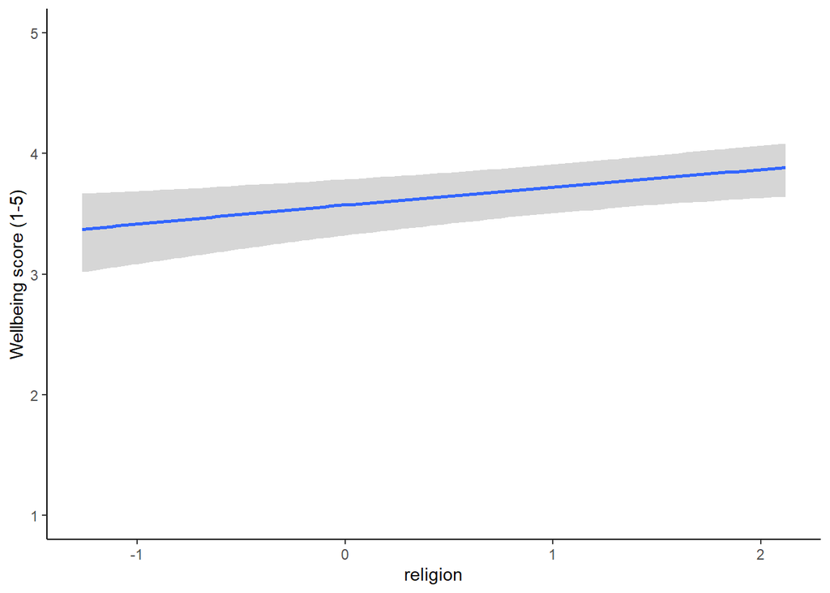

We can also split this effect into separate wellbeing subscales…

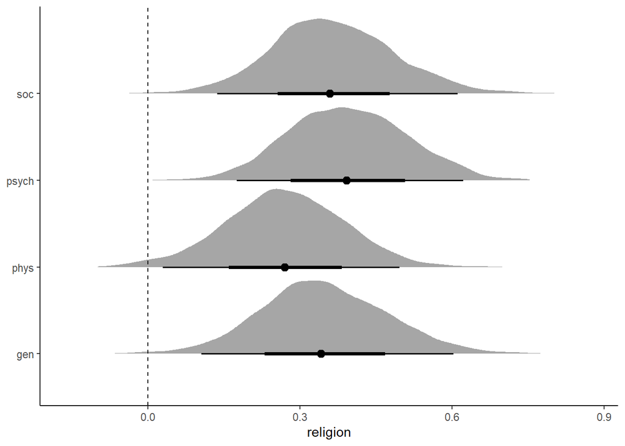

… and by individual wellbeing items…

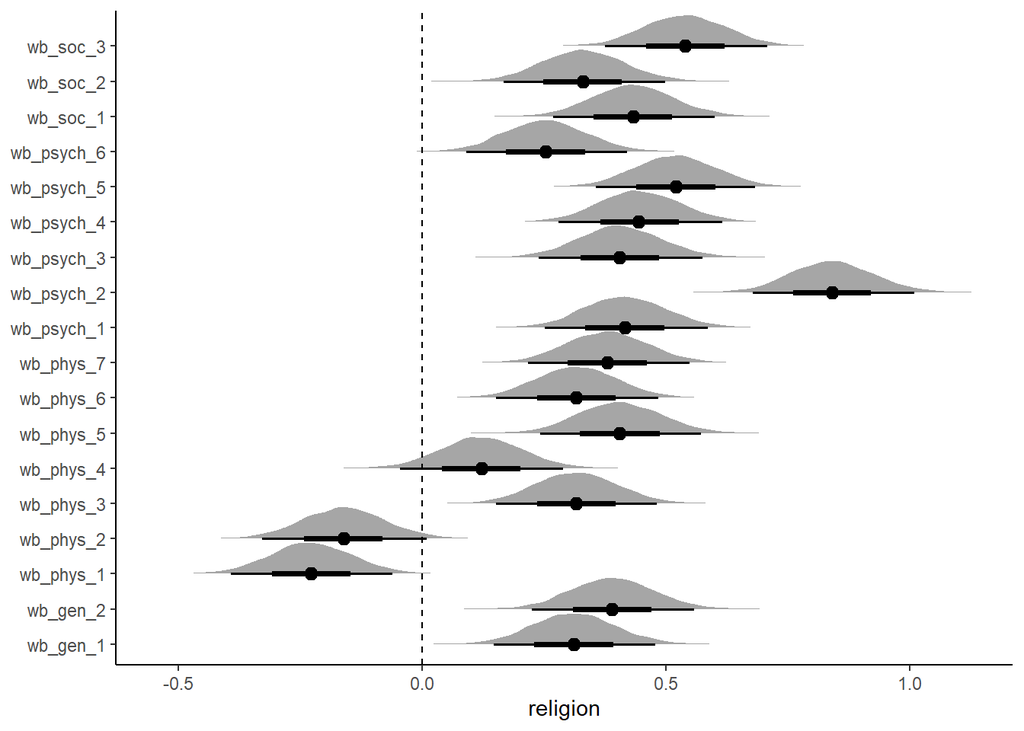

… and by country…

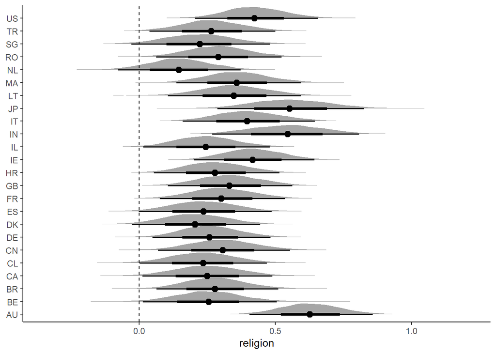

… and by religious denomination.

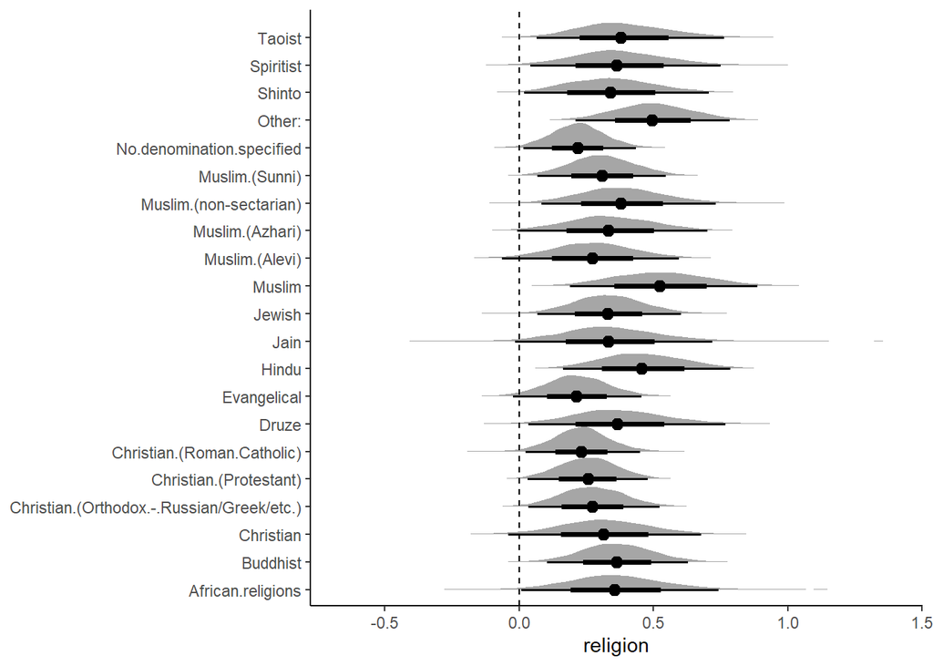

## Question 2: Is there an interaction with perceived cultural norms?

We then add an interaction effect with `cnorm`: `wellbeing ~ 1 + religion*cnorm + (1 + religion*cnorm | subscale/item) + (1 | gr(iso, cov = ling, id = "iso)) + (0 + religion*cnorm | gr(iso, id = "iso")) + (1 + religion*cnorm | denomination) + (1 | subject) + age + gender + gdp_scaled`. In this model, every wellbeing subscale, every individual wellbeing item, every country, and every denomination has its own interaction between religion and cultural norms.

Does this model improve the fit over the previous model? If there’s an interaction effect, we would expect it to.

```
##      elpd_diff se_diff subsampling_se_diff
## m2.3   0.0       0.0     0.0
## m2.2  70.1      35.0   303.6
```

Here’s the summary for this model.

```
##  Family: cumulative
##   Links: mu = logit; disc = identity
## Formula: wellbeing ~ 1 + religion * cnorm + (1 + religion * cnorm | subscale/item) + (1 | gr(iso, cov = ling, id = "iso")) + (0 + religion * cnorm | gr(iso, id = "iso")) + (1 + religion * cnorm | denomination) + (1 | subject) + age + gender + gdp_scaled
##    Data: dLong (Number of observations: 182200)
## Samples: 4 chains, each with iter = 2500; warmup = 1250; thin = 1;
##          total post-warmup samples = 5000
##
## Group-Level Effects:
## ~denomination (Number of levels: 21)
##                               Estimate Est.Error l-95% CI u-95% CI Rhat Bulk_ESS Tail_ESS
## sd(Intercept)                     0.12      0.07     0.01     0.28 1.02      268      609
## sd(religion)                      0.06      0.05     0.00     0.17 1.00      480     1083
## sd(cnorm)                         0.14      0.10     0.01     0.38 1.01      356     1043
## sd(religion:cnorm)                0.08      0.06     0.00     0.23 1.00      625     1441
## cor(Intercept,religion)          -0.36      0.44    -0.94     0.68 1.00      780     1792
## cor(Intercept,cnorm)              0.05      0.43    -0.75     0.81 1.00     1953     2859
## cor(religion,cnorm)              -0.21      0.44    -0.90     0.70 1.00     1515     2566
## cor(Intercept,religion:cnorm)    -0.21      0.44    -0.89     0.71 1.00     1597     2515
## cor(religion,religion:cnorm)     -0.02      0.45    -0.82     0.81 1.00     2584     3600
## cor(cnorm,religion:cnorm)        -0.20      0.46    -0.90     0.74 1.00     1332     2982
##
## ~iso (Number of levels: 24)
##                               Estimate Est.Error l-95% CI u-95% CI Rhat Bulk_ESS Tail_ESS
## sd(Intercept)                     0.53      0.09     0.38     0.72 1.00     1071     1886
## sd(religion)                      0.06      0.04     0.00     0.16 1.00      454      824
## sd(cnorm)                         0.31      0.11     0.10     0.56 1.01      488      977
## sd(religion:cnorm)                0.22      0.10     0.04     0.43 1.01      258      441
## cor(Intercept,religion)          -0.31      0.38    -0.89     0.54 1.00     1387     2123
## cor(Intercept,cnorm)             -0.44      0.25    -0.83     0.13 1.00     1208     1896
## cor(religion,cnorm)               0.11      0.41    -0.68     0.81 1.01      385     1467
## cor(Intercept,religion:cnorm)    -0.26      0.30    -0.78     0.36 1.00     1194     2083
## cor(religion,religion:cnorm)     -0.08      0.45    -0.81     0.78 1.01      445     1315
## cor(cnorm,religion:cnorm)         0.53      0.30    -0.15     0.94 1.00      703     1644
##
## ~subject (Number of levels: 10175)
##               Estimate Est.Error l-95% CI u-95% CI Rhat Bulk_ESS Tail_ESS
## sd(Intercept)     1.29      0.01     1.27     1.31 1.01     1013     2166
##
## ~subscale (Number of levels: 4)
##                               Estimate Est.Error l-95% CI u-95% CI Rhat Bulk_ESS Tail_ESS
```

[output cut: 30 more lines]

```
## religion           0.15      0.10    -0.03     0.35 1.00     1015     1795
## cnorm              0.14      0.19    -0.24     0.50 1.00      992     1743
## age                0.05      0.02     0.02     0.09 1.00      669     1226
## genderother       -0.76      0.17    -1.10    -0.43 1.00      847     1626
## genderwoman       -0.09      0.03    -0.14    -0.03 1.00      578     1372
## gdp_scaled         0.01      0.09    -0.17     0.18 1.01      834     2041
## religion:cnorm     0.21      0.15    -0.10     0.50 1.01     1189     2308
##
## Family Specific Parameters:
##      Estimate Est.Error l-95% CI u-95% CI Rhat Bulk_ESS Tail_ESS
## disc     1.00      0.00     1.00     1.00 1.00     5000     5000
##
## Samples were drawn using sampling(NUTS). For each parameter, Bulk_ESS
## and Tail_ESS are effective sample size measures, and Rhat is the potential
## scale reduction factor on split chains (at convergence, Rhat = 1).
```

The fixed effect `religion:cnorm` is of interest.

Plot the interaction.

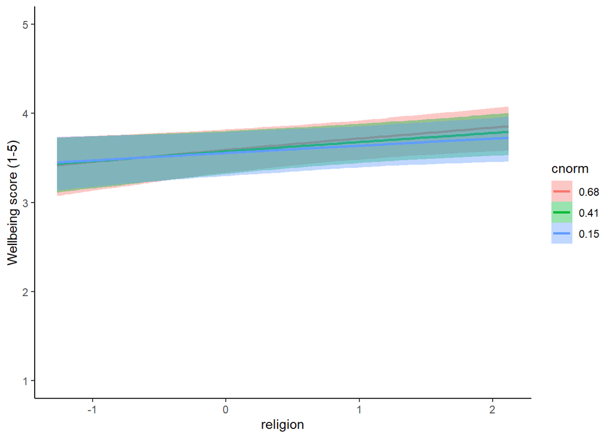

We can also get forest plots of the interaction parameter for wellbeing subscales…

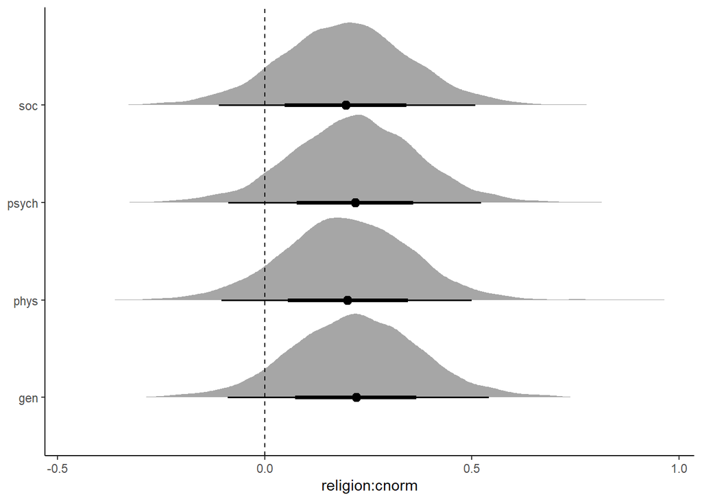

… for individual wellbeing items…

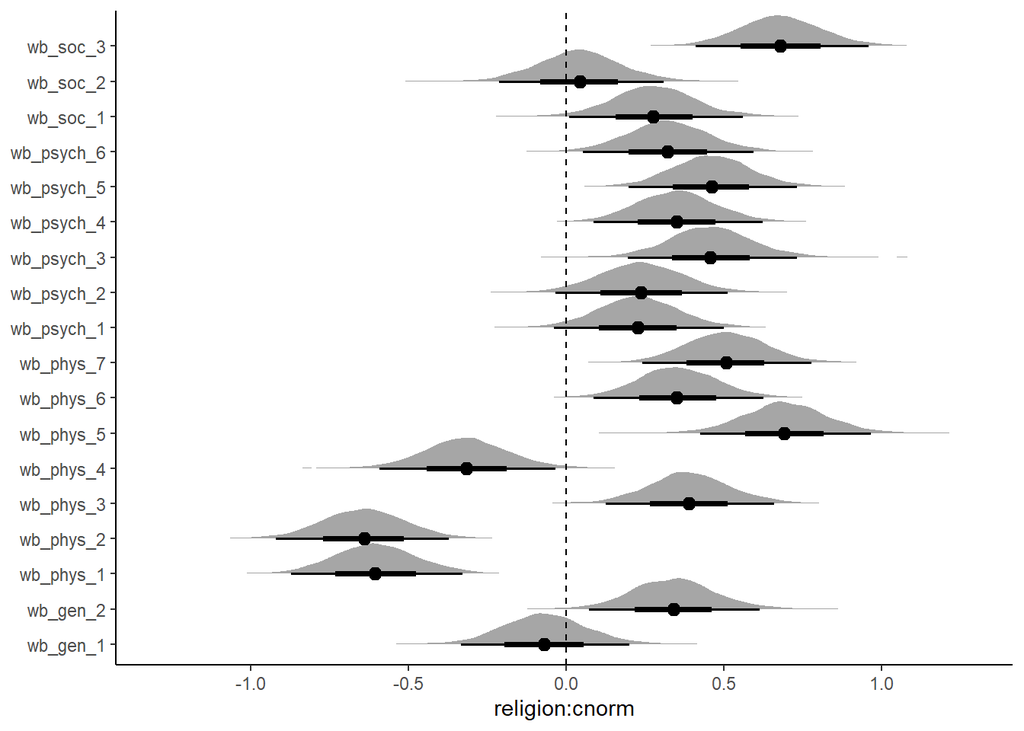

… for countries…

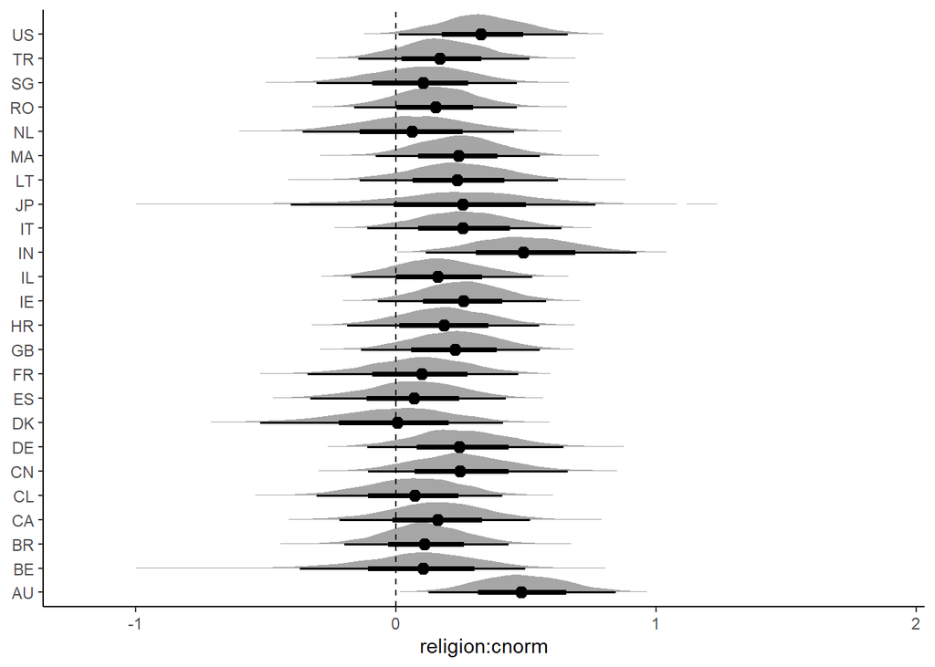

… and for religious denominations.

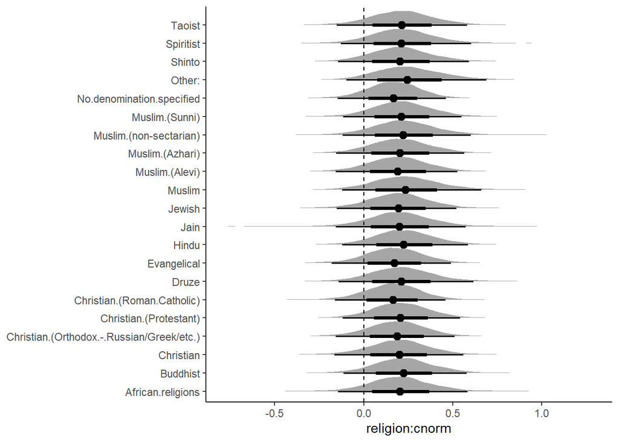